# Multivariate Time Series Forecasting: Nonparametric Vector Autoregression

Fred Viole

Regenerated November 04, 2026

# 1 Introduction

This quick note is intended to introduce the intuition behind the `NNS.VAR` function, which serves as a nonparametric vector autoregression.

Install the latest version of `NNS` and the other required packages…

```r
require(devtools)
install_github("OVVO-Financial/NNS", ref = "NNS-Beta-Version")
```

```r
library(NNS)
library(vars)
library(forecast)
library(randomForest)
packageVersion("NNS")
```

```
## [1] '13.3'
```

# 2 `NNS.VAR` Example with 3 Variables: Fed Funds, Real GNP, and Inflation

Using the log differences of each `Real GNP` and `Inflation`, the previous method creates lowest frequency series. In this illustrative VAR example from Lutz Kilian[^1], `Fed Funds` (monthly) is averaged over 3-period windows to align with quarterly GNP data.

The series come from FRED: `FEDFUNDS` (effective federal funds rate, monthly, percent), `GNPC96` (real gross national product, quarterly) and `GNPDEF` (GNP implicit price deflator, quarterly). The window, 1954 Q4 to 2007 Q4, is the archived page’s 213 quarters. Its interest rates are reproduced exactly; real growth and inflation differ slightly because FRED serves the current vintage of the national accounts.

```r
if (refresh_data) {
  fred_csv <- function(id) {
    x <- read.csv(paste0("https://fred.stlouisfed.org/graph/fredgraph.csv?id=", id),
                  na.strings = ".")
    data.frame(series = id, date = x[[1]], value = x[[2]])
  }
  fred <- rbind(subset(fred_csv("FEDFUNDS"), date >= "1954-10-01" & date <= "2007-12-01"),
                subset(fred_csv("GNPC96"), date >= "1954-07-01" & date <= "2007-10-01"),
                subset(fred_csv("GNPDEF"), date >= "1954-07-01" & date <= "2007-10-01"))
  write.csv(fred[!is.na(fred$value), ], "data/VAR_example_fred.csv", row.names = FALSE)
}

# Load Variables
fred <- read.csv("data/VAR_example_fred.csv")
series <- function(id) setNames(fred$value[fred$series == id], fred$date[fred$series == id])
FF <- series("FEDFUNDS")
realgnp <- series("GNPC96")
gnpdeflator <- series("GNPDEF")

drgdp <- diff(log(realgnp)) * 100
infl <- diff(log(gnpdeflator)) * 100
irate <- tapply(FF, rep(seq_len(length(FF) / 3), each = 3), mean)

y <- cbind(`Diff Real GDP` = drgdp, `Interest Rate` = irate, Inflation = infl)
quarter <- function(d) paste0(substr(d, 1, 4), " Q", (as.integer(substr(d, 6, 7)) + 2) / 3)
rownames(y) <- quarter(names(drgdp))
head(y)
```

```
##         Diff Real GDP Interest Rate Inflation
## 1954 Q4     1.9999445     0.9866667 0.2728515
## 1955 Q1     2.8121352     1.3433333 0.4702088
## 1955 Q2     1.5935371     1.5000000 0.4169263
## 1955 Q3     1.3401432     1.9400000 0.6982862
## 1955 Q4     0.6091209     2.3566667 0.9881432
## 1956 Q1    -0.3160662     2.4833333 0.9926880
```

```r
tail(y)
```

```
##         Diff Real GDP Interest Rate Inflation
## 2006 Q3    0.05335294      5.246667 0.6959648
## 2006 Q4    0.90753669      5.246667 0.3567888
## 2007 Q1    0.28787445      5.256667 0.9472069
## 2007 Q2    0.73225721      5.250000 0.6926727
## 2007 Q3    0.95543047      5.073333 0.5437814
## 2007 Q4    0.90558821      4.496667 0.4087772
```

# 3 Forecast 12 Quarters Out-of-Sample Using All Methods

We will withhold 12 quarters of observations as the `test` set. Let’s see how accurate a VAR, a random forest and `NNS` are…

Why a random forest? The Bank of England has recently been posting working papers utilizing machine learning, specifically random forests:

- [Machine Learning at Central Banks](https://techpolicyinstitute.org/wp-content/uploads/2018/02/Joseph-machine-learning-at-central-banks.pdf)
- [Predicting Bank Distress in the UK with Machine Learning](https://www.bankofengland.co.uk/-/media/boe/files/working-paper/2019/predicting-bank-distress-in-the-uk-with-machine-learning.pdf)

Every method is fit and tuned on the training quarters. The tuning steps hold out the end of the training sample for internal validation; their scores choose settings and are reported as such. Only the final forecasts meet the test quarters.

```r
h <- 12
y_train_VAR <- head(y, nrow(y) - h)
y_test_VAR <- tail(y, h)
span <- function(r) paste(r[1], "to", r[length(r)])
data.frame(Window = c("Training (fit and tune)",
                      "Internal validation: NNS.ARMA.optim, NNS.boost, NNS.stack",
                      "Internal validation: NNS.VAR (pipeline)",
                      "Test (final forecasts only)"),
           Quarters = c(span(rownames(y_train_VAR)),
                        span(tail(rownames(y_train_VAR), 2 * h)),
                        span(tail(rownames(y_train_VAR), 40)),
                        span(rownames(y_test_VAR))),
           Length = c(nrow(y_train_VAR), 2 * h, 40, h))
```

```
##                                                      Window           Quarters
## 1                                   Training (fit and tune) 1954 Q4 to 2004 Q4
## 2 Internal validation: NNS.ARMA.optim, NNS.boost, NNS.stack 1999 Q1 to 2004 Q4
## 3                   Internal validation: NNS.VAR (pipeline) 1995 Q1 to 2004 Q4
## 4                               Test (final forecasts only) 2005 Q1 to 2007 Q4
##   Length
## 1    201
## 2     24
## 3     40
## 4     12
```

The window of `NNS.VAR` is `max(2 * h, 0.2 * (n - tau))` quarters, 40 here; its output below confirms it.

# 4 Traditional VAR

```r
# 4 quarterly lags used in VAR
VAR_train <- VAR(y = y_train_VAR, p = 4)
VAR_test <- predict(VAR_train, n.ahead = h)
VAR_fc <- sapply(VAR_test$fcst, function(f) f[, "fcst"])

rmse <- function(f, a) sqrt(mean((f - a)^2))
# A constant forecast path has no rank correlation: NA.
spearman <- function(f, a) if (sd(f) == 0) NA_real_ else cor(f, a, method = "spearman")
test_scores <- function(fc, label) {
  out <- cbind(sapply(1:3, function(i) rmse(fc[, i], y_test_VAR[, i])),
               sapply(1:3, function(i) spearman(fc[, i], y_test_VAR[, i])))
  dimnames(out) <- list(colnames(y), paste(label, c("RMSE", "Spearman")))
  out
}
VAR_results <- test_scores(VAR_fc, "VAR")
knitr::kable(VAR_results, digits = 4,
             caption = paste("Test scores,", span(rownames(y_test_VAR))))
```

Test scores, 2005 Q1 to 2007 Q4

|  | VAR RMSE | VAR Spearman |
| --- | --- | --- |
| Diff Real GDP | 0.4736 | -0.4545 |
| Interest Rate | 1.1893 | 0.7741 |
| Inflation | 0.3152 | -0.5455 |

The Spearman correlations of the VAR forecasts with the test values are -0.45, 0.77, -0.55 for real growth, the interest rate and inflation.

This highlights the dual objective of differenced time series data:

- Get the sign right
- Get the magnitude right

`NNS` is able to address this dual objective in its routines as detailed in the following code chunks.

# 5 `NNS` and Random Forest

## 5.1 Function to Generate Lagged Variables

The following code is to generate a matrix of lagged variables to be used in both `NNS` and Random Forest routines.

```r
lag.mtx <- function(x, tau) {
  colheads <- NULL
  if (is.null(dim(x)[2])) {
    colheads <- noquote(as.character(deparse(substitute(x))))
    x <- t(t(x))
  }
  j.vectors <- list()
  for (j in 1:ncol(x)) {
    if (is.null(colheads)) {
      colheads <- colnames(x)[j]
      colheads <- noquote(as.character(deparse(substitute(colheads))))
    }
    x.vectors <- list()
    heads <- paste0(colheads, ".tau.")
    heads <- gsub("\"", "", heads)
    for (i in 0:tau) {
      x.vectors[[paste(heads, i, sep = "")]] <- numeric(0L)
      start <- tau - i + 1
      end <- length(x[, j]) - i
      x.vectors[[i + 1]] <- x[start:end, j]
    }
    j.vectors[[j]] <- do.call(cbind, x.vectors)
    colheads <- NULL
  }
  return(as.data.frame(do.call(cbind, j.vectors)))
}

# Test it
set.seed(123)
V1 <- rnorm(10)
V2 <- rnorm(10)
V3 <- rnorm(10)
lag.mtx(cbind(V1 = V1, V2 = V2, V3 = V3), 3)
```

```
##      V1.tau.0    V1.tau.1    V1.tau.2    V1.tau.3   V2.tau.0   V2.tau.1
## 1  0.07050839  1.55870831 -0.23017749 -0.56047565  0.1106827  0.4007715
## 2  0.12928774  0.07050839  1.55870831 -0.23017749 -0.5558411  0.1106827
## 3  1.71506499  0.12928774  0.07050839  1.55870831  1.7869131 -0.5558411
## 4  0.46091621  1.71506499  0.12928774  0.07050839  0.4978505  1.7869131
## 5 -1.26506123  0.46091621  1.71506499  0.12928774 -1.9666172  0.4978505
## 6 -0.68685285 -1.26506123  0.46091621  1.71506499  0.7013559 -1.9666172
## 7 -0.44566197 -0.68685285 -1.26506123  0.46091621 -0.4727914  0.7013559
##     V2.tau.2   V2.tau.3   V3.tau.0   V3.tau.1   V3.tau.2   V3.tau.3
## 1  0.3598138  1.2240818 -0.7288912 -1.0260044 -0.2179749 -1.0678237
## 2  0.4007715  0.3598138 -0.6250393 -0.7288912 -1.0260044 -0.2179749
## 3  0.1106827  0.4007715 -1.6866933 -0.6250393 -0.7288912 -1.0260044
## 4 -0.5558411  0.1106827  0.8377870 -1.6866933 -0.6250393 -0.7288912
## 5  1.7869131 -0.5558411  0.1533731  0.8377870 -1.6866933 -0.6250393
## 6  0.4978505  1.7869131 -1.1381369  0.1533731  0.8377870 -1.6866933
## 7 -1.9666172  0.4978505  1.2538149 -1.1381369  0.1533731  0.8377870
```

```r
# Compare to last values of each variable
cbind(V1 = tail(V1), V2 = tail(V2), V3 = tail(V3))
```

```
##              V1         V2         V3
## [1,]  0.1292877 -0.5558411 -0.6250393
## [2,]  1.7150650  1.7869131 -1.6866933
## [3,]  0.4609162  0.4978505  0.8377870
## [4,] -1.2650612 -1.9666172  0.1533731
## [5,] -0.6868529  0.7013559 -1.1381369
## [6,] -0.4456620 -0.4727914  1.2538149
```

# 6 Predictions

## 6.1 1 Year Lag $(\tau = 4)$, 3 Year Forecast $(h = 12)$

## 6.2 Create Forecasted IVs Using `NNS.ARMA()`

Each series is forecast on its own. `NNS.seas` lists candidate periods, and `NNS.ARMA.optim` chooses among them on the last `2 * h` training quarters.

```r
nns_uni <- lapply(seq_len(ncol(y_train_VAR)), function(i) {
  variable <- y_train_VAR[, i]
  periods <- NNS.seas(variable, modulo = 4, mod.only = FALSE, plot = FALSE)$periods
  NNS.ARMA.optim(variable, h = h, seasonal.factor = periods,
                 training.set = length(variable) - 2 * h, ncores = 1,
                 print.trace = FALSE, obj.fn = expression(sum((predicted - actual)^2)),
                 objective = "min")
})
nns_IVs <- sapply(nns_uni, `[[`, "results")
colnames(nns_IVs) <- colnames(y)

knitr::kable(data.frame(Periods = sapply(nns_uni, function(b) paste(b$periods, collapse = ", ")),
                        Method = sapply(nns_uni, `[[`, "method"),
                        `Validation RMSE` = sqrt(sapply(nns_uni, `[[`, "obj.fn") / (2 * h)),
                        row.names = colnames(y), check.names = FALSE),
             digits = 4,
             caption = paste("NNS.ARMA.optim internal validation,",
                             span(tail(rownames(y_train_VAR), 2 * h)),
                             "(the selected settings' own score)"))
```

NNS.ARMA.optim internal validation, 1999 Q1 to 2004 Q4 (the selected settings’ own score)

|  | Periods | Method | Validation RMSE |
| --- | --- | --- | --- |
| Diff Real GDP | 4, 26, 24, 22, 21, 32, 16 | lin | 0.5086 |
| Interest Rate | 4 | nonlin | 2.9669 |
| Inflation | 1, 4 | both | 0.3759 |

```r
# Test how accurate the univariate NNS.ARMA forecasts are, against auto ARIMA
arma_fc <- sapply(seq_len(ncol(y_train_VAR)), function(i)
  as.numeric(forecast(auto.arima(y_train_VAR[, i]), h = h)$mean))
NNS.ARMA_results <- test_scores(nns_IVs, "NNS ARMA")
auto.ARMA_results <- test_scores(arma_fc, "Auto ARMA")
knitr::kable(cbind(VAR_results, NNS.ARMA_results, auto.ARMA_results), digits = 4,
             caption = paste("Test scores,", span(rownames(y_test_VAR))))
```

Test scores, 2005 Q1 to 2007 Q4

|  | VAR RMSE | VAR Spearman | NNS ARMA RMSE | NNS ARMA Spearman | Auto ARMA RMSE | Auto ARMA Spearman |
| --- | --- | --- | --- | --- | --- | --- |
| Diff Real GDP | 0.4736 | -0.4545 | 0.4219 | 0.2517 | 0.4413 | 0.4196 |
| Interest Rate | 1.1893 | 0.7741 | 3.5853 | -0.3047 | 2.6310 | -0.4812 |
| Inflation | 0.3152 | -0.5455 | 0.1970 | -0.2168 | 0.1810 | NA |

`NA` marks a constant forecast path, which has no rank correlation.

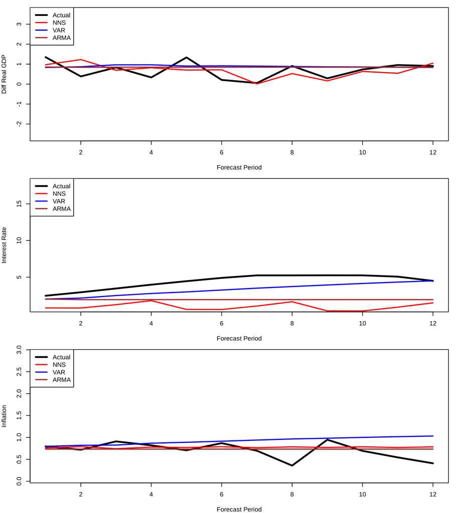

```r
par(mfrow = c(3, 1), mar = c(4, 4, 1, 1))
for (i in 1:3) {
  plot(1:h, y_test_VAR[, i], type = "l", lwd = 3,
       ylim = range(y[, i]), xlab = "Forecast Period", ylab = colnames(y)[i])
  lines(1:h, nns_IVs[, i], col = "red", lwd = 2)
  lines(1:h, VAR_fc[, i], col = "blue", lwd = 2)
  lines(1:h, arma_fc[, i], col = "brown", lwd = 2)
  legend("topleft", col = c("black", "red", "blue", "brown"),
         legend = c("Actual", "NNS", "VAR", "ARMA"), lty = 1, lwd = c(3, 2, 2, 2))
}
```

The archived page also ran Kolmogorov-Smirnov tests between each forecast path and the test values. Those treat the 12 forecasts and the 12 outcomes as two independent samples and compare their spreads, not the forecast errors, so they are not repeated here.

# 7 Use Forecasted IVs in `NNS` and Random Forest

We will now utilize the forecasted variables in the multi-variate `NNS.reg()` function. Our first step is to pass these variables through the `NNS.boost()` function in order to reduce any unnecessary features. The objective function `obj.fn` and objective `objective` are set explicitly, since this is not a classification problem.

From there, we use the reduced variable set (if any reduction) in the `NNS.stack()` function which cross-validates the `n.best` and `threshold` parameters from the `NNS.reg()` function. Both tune on the last `2 * h` rows of the lagged training matrix.

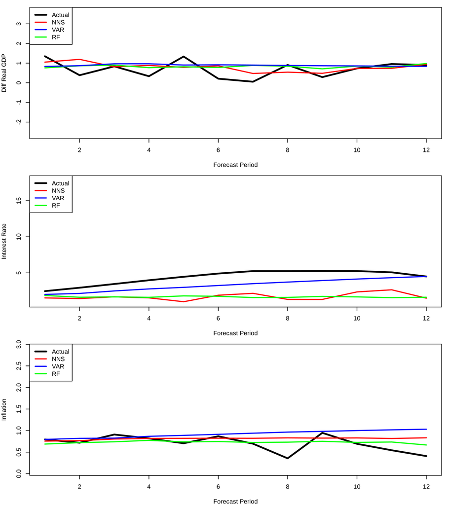

```r
# Combine forecasted IVs onto training data.frame, then lag it
new_values <- rbind(y_train_VAR, nns_IVs)
lagged_new_values <- lag.mtx(new_values, tau = 4)
y_train_nns <- head(lagged_new_values, nrow(lagged_new_values) - h)
y_test_nns <- tail(lagged_new_values, h)

# Select tau = 0 as test set DVs
DVs <- which(grepl("tau.0", colnames(y_train_nns)))
nns_est <- rf_est <- list()
stack_validation <- matrix(NA, 3, 2, dimnames = list(colnames(y), c("Multivariate", "Dimension reduction")))

par(mfrow = c(3, 1), mar = c(4, 4, 1, 1))
for (i in DVs) {
  index <- which(DVs == i)
  # NNS.boost() is an ensemble method comparable to xgboost, and aids in dimension reduction
  nns_boost_est <- NNS.boost(IVs.train = y_train_nns[, -i], DV.train = y_train_nns[, i],
                             IVs.test = y_test_nns[, -i],
                             obj.fn = expression(sum((predicted - actual)^2)), objective = "min",
                             ts.test = 2 * h, learner.trials = 100, epochs = 100, type = NULL,
                             feature.importance = FALSE, folds = 1, status = FALSE)

  # NNS.stack() cross-validates the parameters of the multivariate NNS.reg()
  # and dimension reduction NNS.reg()
  relevant_vars <- colnames(y_train_nns) %in% names(nns_boost_est$feature.weights)
  nns_stack <- NNS.stack(IVs.train = y_train_nns[, relevant_vars], DV.train = y_train_nns[, i],
                         IVs.test = y_test_nns[, relevant_vars], folds = 1, ts.test = 2 * h,
                         order = "max", obj.fn = expression(sum((predicted - actual)^2)),
                         objective = "min", type = "REG", status = FALSE)
  stack_validation[index, ] <- sqrt(c(nns_stack$OBJfn.reg, nns_stack$OBJfn.dim.red) / (2 * h))

  # Ensemble with univariate estimates
  nns_est[[index]] <- (nns_IVs[, index] + nns_stack$stack) / 2

  # Random Forest
  set.seed(123)
  rf <- randomForest(y_train_nns[, -i], y_train_nns[, i], ntree = 100)
  rf_est[[index]] <- predict(rf, newdata = y_test_nns[, -i])

  # Plot all results
  plot(1:h, y_test_VAR[, index], type = "l", lwd = 3, ylim = range(y[, index]),
       xlab = "Forecast Period", ylab = colnames(y)[index])
  lines(1:h, nns_est[[index]], col = "red", lwd = 2)
  lines(1:h, rf_est[[index]], col = "green", lwd = 2)
  lines(1:h, VAR_fc[, index], col = "blue", lwd = 2)
  legend("topleft", col = c("black", "red", "blue", "green"),
         legend = c("Actual", "NNS", "VAR", "RF"), lty = 1, lwd = c(3, 2, 2, 2))
}
```

```r
nns_est <- do.call(cbind, nns_est)
rf_est <- do.call(cbind, rf_est)
```

```r
knitr::kable(stack_validation, digits = 4,
             caption = paste("NNS.stack internal validation RMSE,",
                             span(tail(rownames(y_train_VAR), 2 * h)),
                             "(best tuned value of each component)"))
```

NNS.stack internal validation RMSE, 1999 Q1 to 2004 Q4 (best tuned value of each component)

|  | Multivariate | Dimension reduction |
| --- | --- | --- |
| Diff Real GDP | 0.6180 | 0.7185 |
| Interest Rate | 0.7055 | 0.7055 |
| Inflation | 0.1234 | 0.1478 |

```r
ALL_RESULTS <- cbind(VAR_results, NNS.ARMA_results,
                     test_scores(nns_est, "NNS"), test_scores(rf_est, "RF"))
knitr::kable(ALL_RESULTS, digits = 4,
             caption = paste("Test scores,", span(rownames(y_test_VAR))))
```

Test scores, 2005 Q1 to 2007 Q4

|  | VAR RMSE | VAR Spearman | NNS ARMA RMSE | NNS ARMA Spearman | NNS RMSE | NNS Spearman | RF RMSE | RF Spearman |
| --- | --- | --- | --- | --- | --- | --- | --- | --- |
| Diff Real GDP | 0.4736 | -0.4545 | 0.4219 | 0.2517 | 0.4252 | 0.2797 | 0.4365 | -0.0350 |
| Interest Rate | 1.1893 | 0.7741 | 3.5853 | -0.3047 | 2.8388 | 0.1506 | 2.8902 | -0.3328 |
| Inflation | 0.3152 | -0.5455 | 0.1970 | -0.2168 | 0.2158 | -0.4266 | 0.1688 | 0.6014 |

# 8 `NNS.VAR()`

The `NNS.VAR()` function now accomplishes all of the prior steps in a single line of code. By default (`naive.weights = TRUE`) its ensemble weights the univariate and multivariate forecasts equally.

`NNS.VAR` tunes on its own chronological holdout inside the training sample. With the default `validation = "pipeline"`, the holdout’s lagged predictors are built from each series’ forecasts made at the holdout’s origin, as they would be in use, and only observed holdout values are scored.

```r
nns_var_estimates <- NNS.VAR(y_train_VAR, h = 12, tau = 4, ncores = 1, status = FALSE)
nns_var_estimates[c("univariate", "multivariate", "ensemble")]
```

```
## $univariate
##    Diff Real GDP Interest Rate Inflation
## 1     0.82814022     0.8046048 0.7093257
## 2     1.00519194     0.7999880 0.8108108
## 3     0.81096376     1.2529738 0.6288988
## 4     1.02047434     1.7980747 0.7769212
## 5     0.59744954     0.6052628 0.7060400
## 6     0.78604045     0.5961426 0.8158548
## 7    -0.08851319     1.0651605 0.6222877
## 8     0.54819132     1.6492681 0.7817826
## 9     0.19271272     0.4074485 0.7022473
## 10    0.52556658     0.3948484 0.8205256
## 11    0.37527367     0.9092798 0.6154359
## 12    0.92968721     1.4983938 0.7867890
##
```

[output cut: 29 more lines]

```r
nns_var_estimates$validation
```

```
## $mode
## [1] "pipeline"
##
## $origin
## [1] 161
##
## $horizon
## [1] 40
##
## $observed.targets
## Diff Real GDP Interest Rate     Inflation
##            40            40            40
```

The holdout starts after training quarter 161 (1994 Q4) and covers 40 quarters.

```r
NNS_VAR_results <- rbind(test_scores(as.matrix(nns_var_estimates$univariate), "x"),
                         test_scores(as.matrix(nns_var_estimates$multivariate), "x"),
                         test_scores(as.matrix(nns_var_estimates$ensemble), "x"))
NNS_VAR_results <- data.frame(Forecast = rep(c("univariate", "multivariate", "ensemble"), each = 3),
                              Variable = rep(colnames(y), 3),
                              RMSE = NNS_VAR_results[, 1], Spearman = NNS_VAR_results[, 2])
knitr::kable(NNS_VAR_results, digits = 4, row.names = FALSE,
             caption = paste("NNS.VAR test scores,", span(rownames(y_test_VAR))))
```

NNS.VAR test scores, 2005 Q1 to 2007 Q4

| Forecast | Variable | RMSE | Spearman |
| --- | --- | --- | --- |
| univariate | Diff Real GDP | 0.4607 | 0.1818 |
| univariate | Interest Rate | 3.5853 | -0.3047 |
| univariate | Inflation | 0.2060 | -0.1259 |
| multivariate | Diff Real GDP | 0.5921 | 0.1089 |
| multivariate | Interest Rate | 3.2764 | -0.3949 |
| multivariate | Inflation | 0.1934 | 0.2098 |
| ensemble | Diff Real GDP | 0.4527 | 0.1748 |
| ensemble | Interest Rate | 3.4152 | -0.5289 |
| ensemble | Inflation | 0.1853 | -0.1259 |

# 9 Comparing the Methods

```r
rmse_table <- cbind(VAR = VAR_results[, 1], `NNS ARMA` = NNS.ARMA_results[, 1],
                    `Auto ARMA` = auto.ARMA_results[, 1],
                    `NNS (boost + stack)` = ALL_RESULTS[, "NNS RMSE"],
                    RF = ALL_RESULTS[, "RF RMSE"],
                    `NNS.VAR ensemble` = NNS_VAR_results$RMSE[NNS_VAR_results$Forecast == "ensemble"])
knitr::kable(rmse_table, digits = 4,
             caption = paste("Test RMSE by method,", span(rownames(y_test_VAR))))
```

Test RMSE by method, 2005 Q1 to 2007 Q4

|  | VAR | NNS ARMA | Auto ARMA | NNS (boost + stack) | RF | NNS.VAR ensemble |
| --- | --- | --- | --- | --- | --- | --- |
| Diff Real GDP | 0.4736 | 0.4219 | 0.4413 | 0.4252 | 0.4365 | 0.4527 |
| Interest Rate | 1.1893 | 3.5853 | 2.6310 | 2.8388 | 2.8902 | 3.4152 |
| Inflation | 0.3152 | 0.1970 | 0.1810 | 0.2158 | 0.1688 | 0.1853 |

These are scores from one forecast origin: 12 quarters for each of three series. They describe this window. Ranking the methods would need several forecast origins (rolling or expanding windows) with the same data, origins, horizon and tuning budget for every method. The internal validation tables above are the scores each `NNS` step optimized; they are not estimates of test accuracy.

> **Note (2026).** This page was rebuilt with the current `NNS`. The archived page’s tables came from an earlier data vintage and `NNS` version and are not carried forward. `NNS.ARMA.optim` no longer adds a validation bias shift by default (`bias.correction = "none"`), and `NNS.VAR` now validates with predictors built from forecasts. The Kolmogorov-Smirnov section is withdrawn (see above). See `examples/example-corrections.md`.
[^1]: Kilian, L. and Lütkepohl, H. (2017) *Structural Vector Autoregressive Analysis*, Cambridge University Press. The archived page linked the textbook data at https://sites.google.com/site/lkilian2019/.